# Project Group - 8

**Members:** \ Jelmer van Gestel (4868420) \ Donna Bouman (5112184)\ Aditya Pavadad (6004695)\ Willemijn Mulder (4954610)\ Raihan Bagus Sakti Aji (5466547)

# Introduction

The emergence of the COVID-19 pandemic in late 2019 triggered an unparalleled global crisis, testing the resilience and adaptability of various economic sectors worldwide. One sector that felt a particularly profound impact was the freight industry, where disruptions have rippled across various modes, including road, railway, and inland waterways. In a concerted effort to curb the spread of the virus, nations around the world implemented travel bans, disrupting the flow of essential goods and challenging the maintenance of supply chains. This disruption extended even to trade within the European Union, where traditionally open borders saw restrictions on the import and export of certain goods between member states. An examination of how this unprecedented crisis affected the freight industry provides valuable insights into understanding the day-to-day operations of the logistics sector. This research aims to provide a deeper understanding of the pandemic’s impact on the transportation sector in the Netherlands. Given its pivotal role in the import and export of goods in Europe, the Netherlands is an especially pertinent case for study. The country's strategic location, advanced infrastructure, robust logistic networks, and skilled workforce all contribute to its significance in the European logistics landscape.

# Research Objective

For this research, we investigated the impact of the COVID-19 pandemic on the freight industry in the Netherlands. The main research question guiding this study is: \ **What is the effect of the COVID-19 pandemic on the Dutch freight industry?**

To delve into this overarching question, we formulated two specific subquestions:

1. *What is the overall influence of COVID-19 on each sector within the freight industry?*
2. *Which specific categories of goods within each sector experienced notable effects during the COVID-19 pandemic?*

- Road transportation
- Rail transportation
- Inland waterways transportation

- Products of agriculture, hunting, and forestry; fish and other fishing products
- Coal and lignite; crude petroleum and natural gas
- Metal ores and other mining and quarrying products; peat; uranium and thorium
- Food products, beverages and tobacco
- Textiles and textile products; leather and leather products
- Wood and products of wood and cork (except furniture); articles of straw and plaiting materials; pulp, paper and paper products; printed matter and recorded media
- Coke and refined petroleum products
- Chemicals, chemical products, and man-made fibers; rubber and plastic products ; nuclear fuel
- Other non metallic mineral products
- Basic metals; fabricated metal products, except machinery and equipment
- Machinery and equipment n.e.c.; office machinery and computers; electrical machinery and apparatus n.e.c.; radio, television and communication equipment and apparatus; medical, precision and optical instruments; watches and clocks
- Transport equipment
- Furniture; other manufactured goods n.e.c.
- Secondary raw materials; municipal wastes and other wastes
- Equipment and material utilized in the transport of goods
- Goods moved in the course of household and office removals; baggage and articles accompanying travellers; motor vehicles being moved for repair; other non market goods n.e.c.
- Grouped goods: a mixture of types of goods which are transported together
- Unidentifiable goods: goods which for any reason cannot be identified and therefore cannot be assigned to groups 01-16.

The transportation of goods by plane was excluded from the analysis as planes transport a different category of goods, often goods that are light and need quick transportation like fruit and flowers. This creates an uneven comparison between good categories across the different industries. Therefor, the flight sector was excluded from the research Furthermore, in addressing the freight industry, this report exclusively concentrates on inland waterway transportation within the Netherlands, excluding overseas shipments to maintain a focused scope.

# Hypothesis Statement

To determine whether a specific industry and material type were impacted by COVID-19 regulations, it is crucial to pinpoint the year when these regulations began to influence the freight industry. The first confirmed COVID-19 diagnosis in the Netherlands occurred on February 2nd, 2020. Shortly thereafter, in March, the initial set of lockdown measures was announced (Ministerie van Algemene Zaken, 2023). These measures included restrictions on freight and transportation in an effort to curb the spread of the virus, leading to a noticeable decline in the total volume of goods transported to and from the Netherlands across all sectors of the freight industry. Given that the research data is reported on an annual basis, we decided to focus on significant shifts in 2020 when compared to the years preceding COVID-19 (from 2015) and the subsequent years after COVID-19 (2022). With this timeframe in mind, the following hypotheses are formulated:

**H0:**

There is no statistically significant change (less than a 5% increase or decrease) during the COVID-19 years (2018 - 2020) and the post-COVID years (2020 - 2022). **H1:**

There is a statistically significant change (greater than a 5% increase or decrease) during the COVID-19 years (2018 - 2020) and the post-COVID years (2020 - 2022).

# Macro analysis Over-All Transport

This plot illustrates a notable shift in the behavior of the freight industry around 2020. Although the change from 2019 to 2020 is marginally less than 2%, and from 2020 to 2021 is under 5%, supporting the acceptance of the null hypothesis (H0) and the rejection of the alternative hypothesis (H1), there is still a discernible impact shown in the graph's trajectory. The ascending trend observed from 2015 to 2019 is unsurprising, given the steady economic growth in the Netherlands during that period (Centraal Bureau voor de Statistiek, n.d.-a). A growing economy typically correlates with an increase in goods transportation. However, this upward trajectory notably deviated in 2020, prompting a closer examination of that particular year.

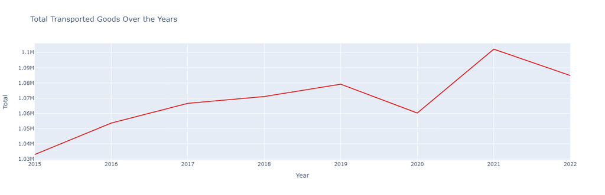

A second graph was created to view the total transportation of goods seperated in the chosen industries.

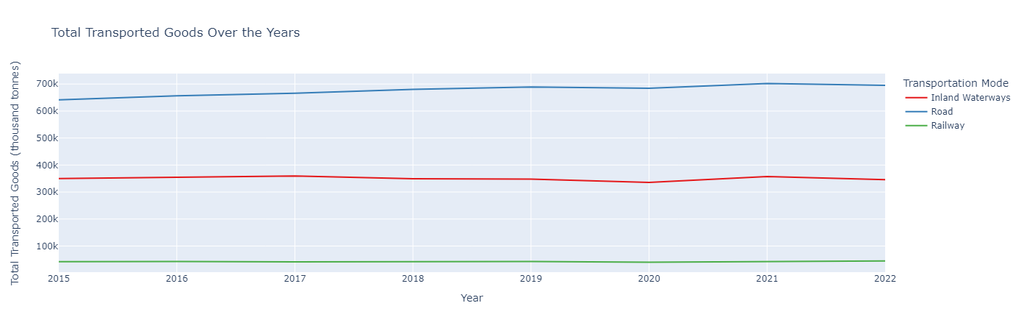

As this plot of the macro view of the industry does not produce clear behaviour changes, each industry will be explored in more detail to more clearly view the changes in transported goods. Because each sector varies in amount of goods fluctuations.

# Freight by road

A large and dependable road network serves the Netherlands' road freight transportation needs, given its central European location. With one of the most advanced infrastructures in the world and a prominent position in global logistics, the nation serves as a hub for the flow of goods both domestically and internationally. Strict industry restrictions take innovation and sustainability into account. The road goods transport system in the Netherlands is renowned for its collaborative efforts with ports and its focus on using innovative technology that reduce the negative effects of supply management.

The market size, measured by revenue, of the Freight Road Transport in the Netherlands industry is €21.9bn in 2023. Ranking them 6th in Europe.The market size of the Freight Road Transport in the Netherlands industry has declined 2.0% per year on average between 2018 and 2023 [10].

The below graph shows the total amount of goods transported (in Thousand tonnes) by road from 2015 - 2022

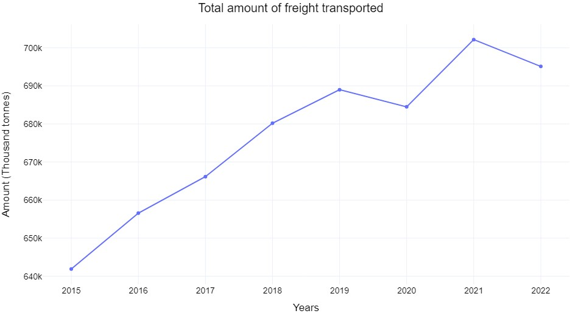

All in all, there was an upward movement in the quantity of goods transported ( thousand tonnes)from year to year starting from 2015 up until it hit its maximum level of 688,995 thousand tonnes in the year 2019. Nevertheless, the decline in this trend can be noticed starting from the year 2020 – to precisely 684,492 thousand tonnes. The decrease of about 0.66% was due to the Covid – 19 pandemic. Pandemic caused chaos in several fields like lock downs, supply chain breakage, as well as people’s purchasing habits. Taken together, all those factors led to a reduction in total shipped goods. In 2021, there was a rebound and about 2.56% rise in the transported goods from that in 2020 when the pandemic struck. However, in 2022, there was a minor drop by about 1.00%, which signifies the changing international environment. Changes in the level of goods transported testify to its resistance and flexibility due to the impact of the coronavirus infection. The dip in 2020 was due to a number of factors, including: Reduced demand for goods: Consumers spent their resources on necessities instead of buying unnecessary commodities due to the outbreak of COVID-19. These were many reasons behind it, such as job loss, reduced income and uncertainties towards the future.

**Disrupted supply chains**:

It was hard time for companies to acquire supplies in the course of the coronavirus pandemic as worldwide logistics were disturbed by it. There were several reasons why this occurred such as border closure, lockdowns, and lack of workforce.

**Increased costs**:

The increased cost of transporting goods during the COVID-19 pandemic. Some of the key reasons included; introduction of new safety measures, surge in price of fuels, as well as break in the supply chain.

Post 2020, the movement of merchandise increased. This rise was due to a number of factors, including:

**Increased demand for goods**:

However, with the gradual diminishing of the covid-19 pandemic demands for goods have begun to rise again. Several reasons accounted for this such as resumption of economics, increased purchasing power and e-commerce growth.

**Improved supply chains**:

After 2020, global supply chains started improving allowing businesses easy accessibility of the commodities that they required for their operations. There were many reasons behind this, some being; opening up of borders again, loosened lockdown measures and increased labour availability.

**Decreased costs**:

Following this, in 2020, the cost of transport went down. The reduction in oil prices, optimization of supply chain and diminishing demand for additional safety precautions were some of the reasons behind this.

Looking at the overview of the road transport, the below graph shows the distribution of road freight transportation based on the type good.

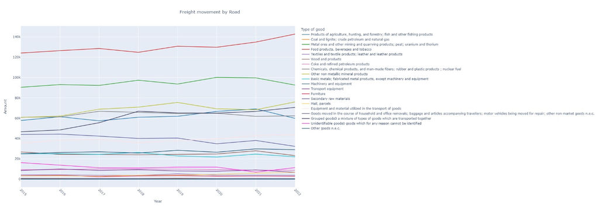

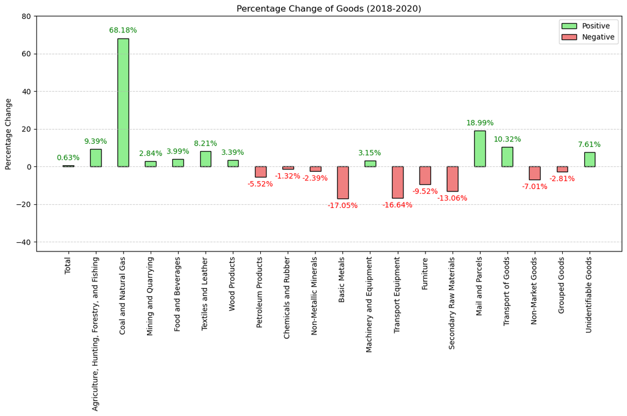

The percentage difference in road freight conveying various kinds of commodities between 2018 and 2020 is seen in this graph. The COVID-19 pandemic had a significant impact on road freight in 2020, leading to supply chain disruptions, a decline in the demand for commodities on the market, and an increase in transportation costs. There affecting the overall global transportation.

A pandemic is typically accompanied by a number of challenges. On the other hand, compared to 2018 data, mail and package transportation had a 18.99% rise during this time. Given that many stayed at home during the pandemic and turned to internet trade, there's a good chance that this increase was caused by the growth of e-commerce.

In addition, between 2018 and 2020, the flow of food, beverages, and cigarettes increased by 4%. These essentials were purchased during the COVID-19 pandemic. Furthermore, it's likely that people will cook more at home as a result of the pandemic closing pubs and restaurants, which would increase the need for food and drink deliveries.

But between 2018 and 2020, there was 2.3% and 17% decrease in the transportation of non-metallic minerals and basic metals, respectively. This may have resulted from the manufacturing and construction industries' slowdown during the outbreak. Due to the epidemic, most building projects were placed on hold, and businesses were forced to reduce their output.

The demand for non-metallic minerals , which are essential as raw materials for the majority of industrial and building processes, decreased as a result. For example : Limestone is the nonmetallic mineral that is used as a building material and also in the manufacture of steel.

Petroleum products saw a drop of 5.52% , as there many travel restrictions in place and the commute was restricted.

There was a steady rise in the total amount transported from to 2019 , before falling to around 685000 thousand tonnes in 2020

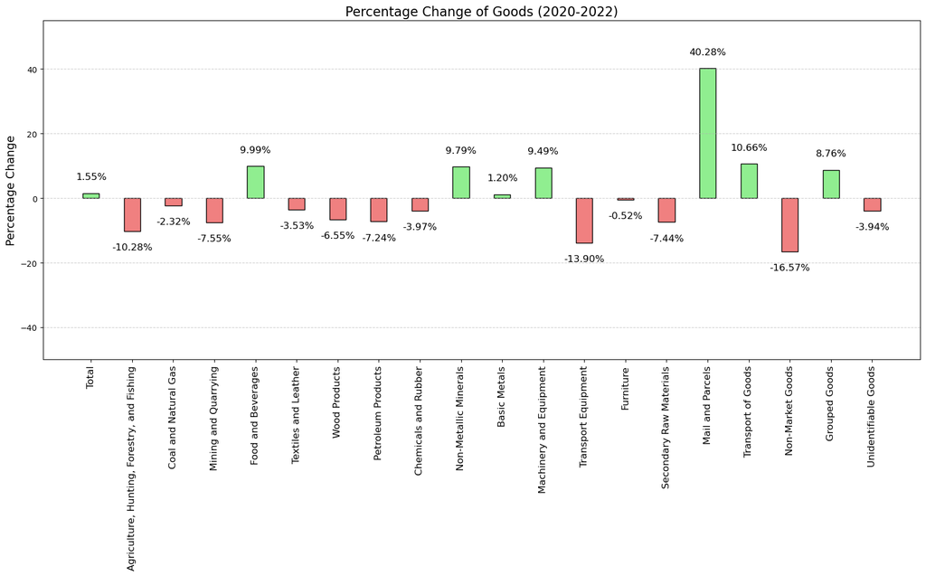

Examining the movement of goods on roads from 2020 to 2022 paints a detailed picture of how things shifted due to the big impact of COVID-19. During this time, the overall stuff moved by road went up a bit, about 1.55%. This might not seem like a lot, but when you think about all the disruptions caused by the pandemic, it becomes more important.

Agriculture took a hit, going down by a significant 10.28%. This happened because of lockdowns, not enough workers, and problems with moving things around. With restrictions in place, it became hard to get goods from farms to where they needed to go, leading to a big drop in how much agricultural stuff got transported.

In conclusion, the movement of goods by road from 2020 to 2022 went through a lot of changes due to the big impact of the COVID-19 pandemic. The different shifts in sectors show how industries adapted to tough situations. As the world keeps dealing with the effects of the pandemic, these trends give useful insights into how things are changing in the transportation world and suggest that being ready for change is key.

# Freight by rail

Rail freight transport plays a vital role in the global logistics chain, offering a blend of reliability, capacity, and environmental efficiency. Countries with extensive rail networks, such as the United States, China, Russia, and India, leverage their railway systems to support their massive freight transportation needs. These rail networks are critical for the movement of bulk commodities, manufactured goods, and intermodal traffic, linking production sites, ports, and urban distribution centers.

In contrast to road transportation, rail freight offers distinct advantages in terms of fuel efficiency and capacity. Trains can move a large volume of goods over long distances with significantly lower fuel consumption per ton-mile compared to trucks. This efficiency makes rail an attractive option for bulk commodities like coal, agricultural products, minerals, and automotive products.

The overall freight and logistics market in the Netherlands is estimated at 70.08 billion USD in 2023 and is expected to reach 92.52 billion USD by 2029, growing at a CAGR of 4.74% during the forecast period (2023-2029) according to a report provided by Mordor Intelligence titled Netherlands Freight And Logistics Market Size & Share Analysis - Growth Trends & Forecasts (2023 - 2028) (Netherlands Freight and Logistics Market Insights, n.d.).

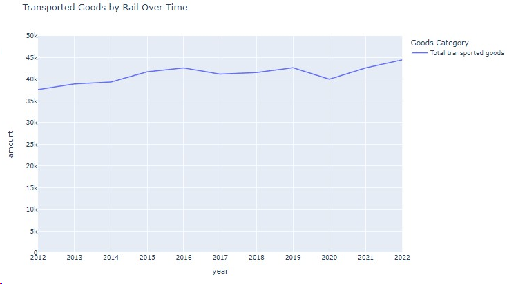

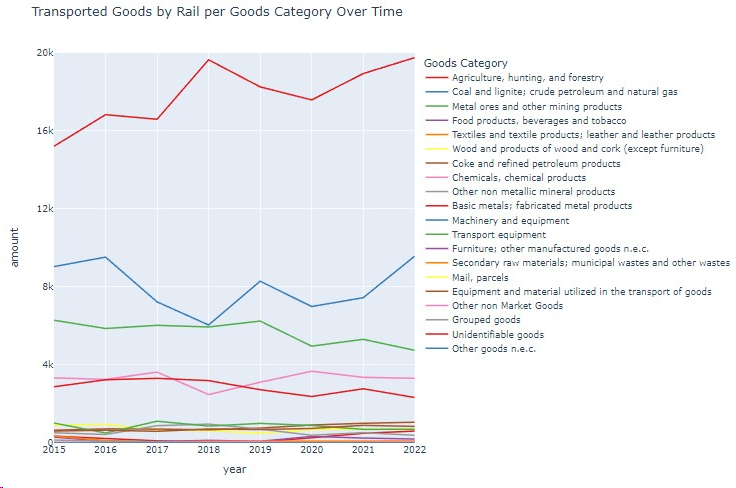

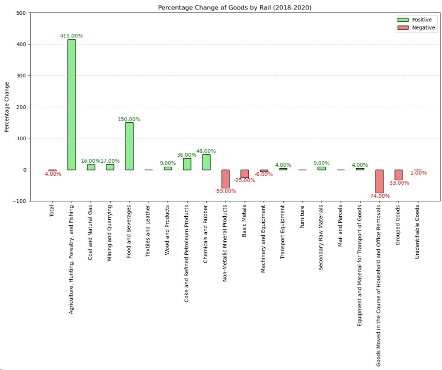

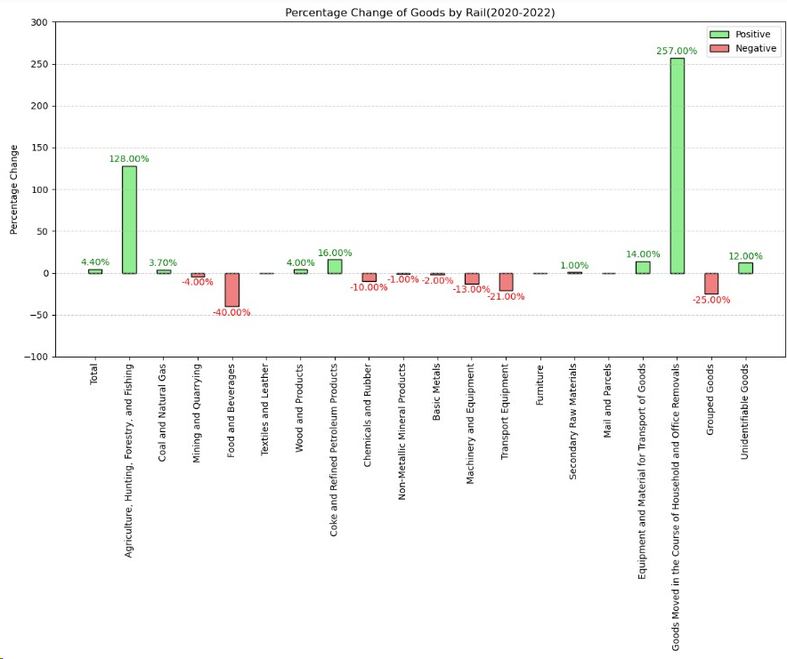

The two graphs above show a comparative analysis of the percentage increase and decrease in the categories of goods transported by rail in the Netherlands during two distinct periods, 2018-2020 and 2020-2022, with the demarcation intended to capture the impact of the COVID-19 pandemic. The first period likely encompasses the initial shock of the pandemic, while the second reflects the ongoing adjustments and recovery.

# Freight by inland waterways

In this section, the freight being transported by inland waterways is explored. This exploration contains a comprehensive overview, including a total graph illustrating the overall volume dynamics. Furthermore, insight in the specific categories of goods is given. To clarify the impact, a detailed percentage breakdown chart is presented, which can be used to determine whether the previously mentioned hypothesis can be accepted.

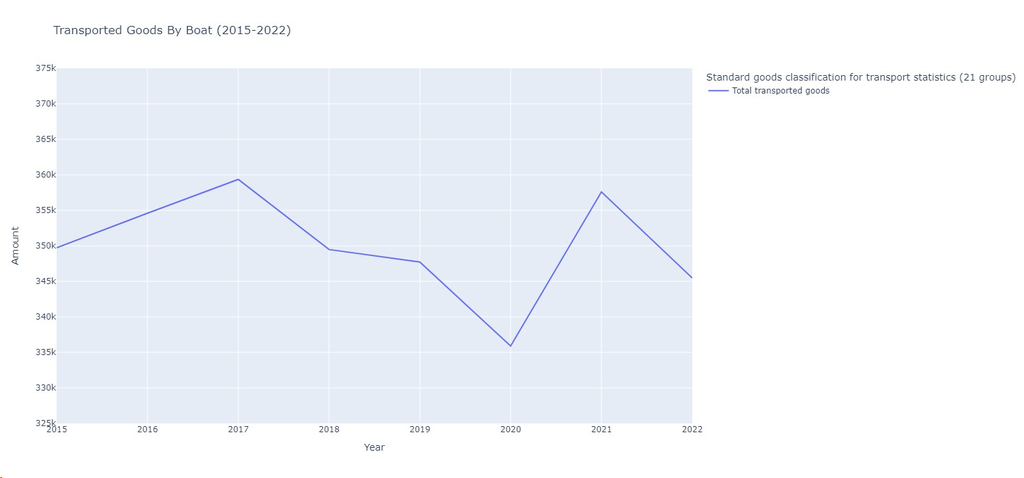

In the graph shown above, the total amount of goods being transported by inland waterways from 2015 till 2022 in the Netherlands is presented. From this graph, it can be observed that in the year 2020, when COVID-19 regulations regarding transportation are implemented, a clear decline is evident. However, considering the initial decrease in 2018, predating the existence of COVID-19 and the transport-related implementations, it is not yet conclusive whether the drop in 2020 is significant. This needs further investigation. Additionally, there is a notable increase in the year 2021, indicating a rise post the COVID period. However, given the decline in the number of transported goods in 2022, this cannot be stated with full certainty. Hence, later in this section, a study on the percentage impact will be conducted.

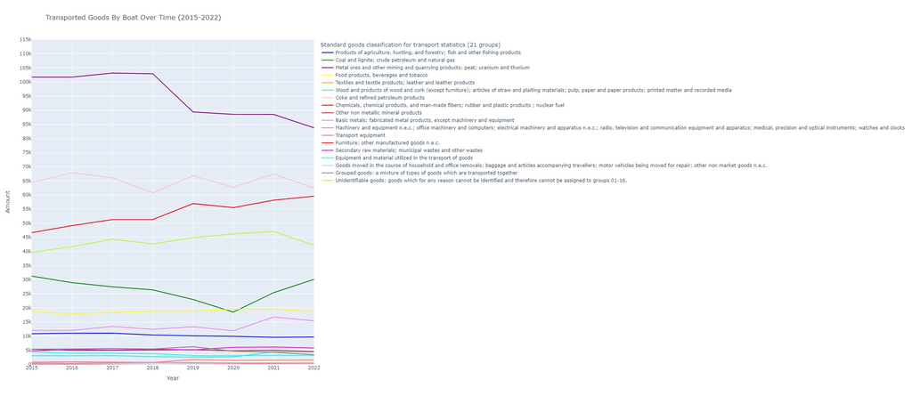

This chart portrays the volume of goods for each specified category, as outlined in the research objective, transported via inland waterways in the Netherlands from 2015 to 2022. Metal ores and other mining and quarrying products; peat; uranium and thorium represent the majority of transported goods. The graph indicates a decline in the quantity of this good in 2019, no significant change in 2019-2020, and a continuation of the previous decline in 2022 to a reasonably similar extent. The lack of significant change in 2019-2020 could be a reflection of the stabilization of certain economic sectors during ongoing challenges. The continuation of the decline in 2022 may be a result of persistent uncertainties and adaptations in response to the evolving pandemic situation. The categories Coke and refined petroleum products, Chemicals, chemical products, and man-made fibers; rubber and plastic products ; nuclear fuel, and Food products, beverages and tobacco show a constant overall change during 2015-2022. This suggests that COVID had a low impact on the transportation of these categories. This is due to the fact that these goods are commonly used in various industrial processes, and industrial activities may have remained relatively stable or adapted quickly to the changing circumstances during the pandemic. The category Coal and lignite; crude petroleum and natural gas does show a visible decline in 2020, compared to 2015-2019. And an increase in the years after, 2021-2022.

However, to draw more definitive conclusions regarding the fluctuations in the transportation of these goods, a thorough analysis on the significance of these changes is necessary. The outcome of this research is presented in the following graphs:

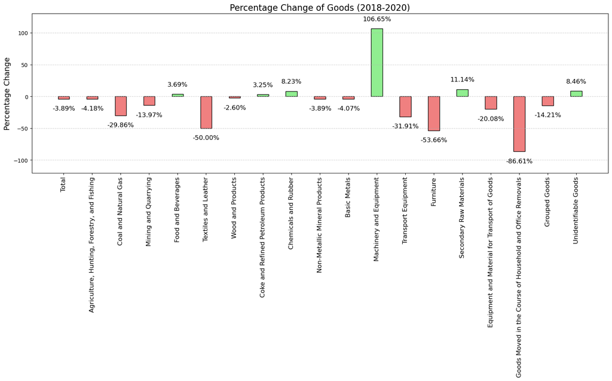

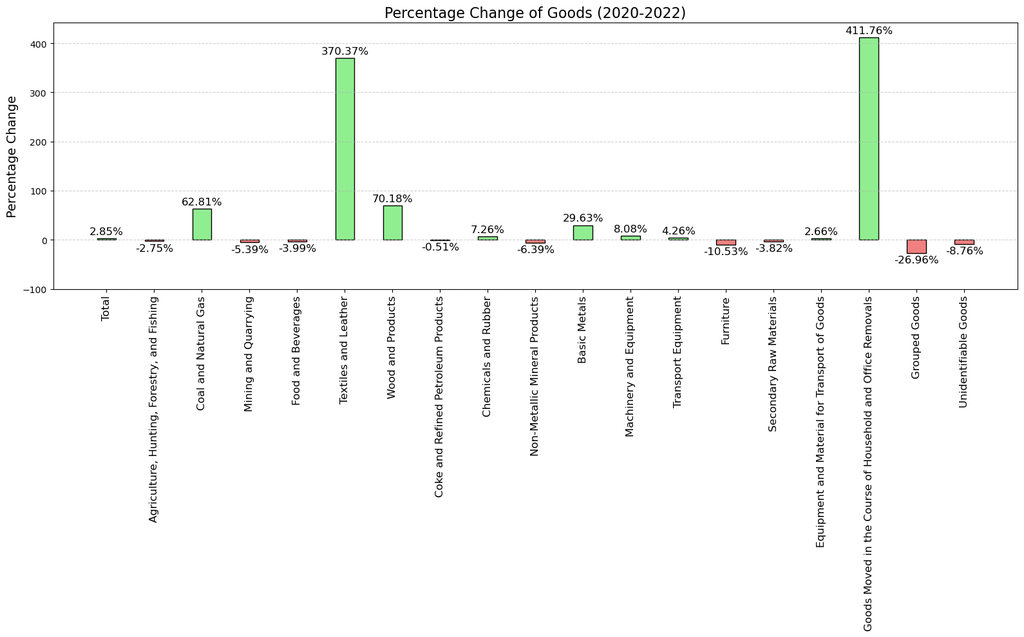

# Conclusion

1. *What is the overall influence of COVID-19 on each sector within the freight industry?*
- Road transportation

**Forcast**

Considering the observed trends from 2015 to 2022, an estimation of the possible change in future freight transportation can be made. While some transportation modes may experience a rebound post-COVID era, others might undergo continued fluctuations. The overall volume of transported goods is expected to reflect a dynamic pattern, potentially influenced by economic recovery, regulatory changes, and shifts in consumer demands. Freight being transported by railway will probably increase to meet the growing demand due to the overall expansion of the freight and logistics market in the Netherlands, with a projected Compound Annual Growth Rate (CAGR) of 4.74% during the forecast period (2023-2029) (Netherlands Freight and Logistics Market Insights, n.d.). The Netherlands Road Freight Transport Market is projected to register a CAGR of 2.82%[9]. Freight transported via inland waterways will probably continue to exhibit stability and consistent activity patterns, as the covid pandemic had no significant impact on the amount of goods being transported via this mode.

A more detailed analysis is recommended to provide a precise forecast, taking into account evolving conditions and potential externalities.

# Contribution Statement

**Author 1**: Gathering data about goods tranpsorted by road: Willemijn

Road freight transport by type of goods and type of transport (t, tkm) - annual data. (2023, July 24). Eurostat. https://ec.europa.eu/eurostat/databrowser/view/road_go_ta_tg__custom_8084260/default/table?lang=en

**Author 2**: Gathering data about goods transported by rail: Raihan

1. Rail data analysis (data gathering, graph coding, narratives)
2. Additional data gathering for Inland waterways & road

   Goods transported by group of goods - from 2008 onwards based on NST 2007. (2023, September 6). Eurostat. https://ec.europa.eu/eurostat/databrowser/view/rail_go_grpgood__custom_8084506/default/table?lang=en

**Author 3**: Gathering data about goods tranpsorted by road: Aditya

1. Road data analysis (data gathering, graph coding, narratives)
2. Formatting and editing the final report.

Road freight transport by type of goods and type of transport (t, tkm) - annual data. (2023, July 24). Eurostat. https://ec.europa.eu/eurostat/databrowser/view/road_go_ta_tg__custom_8084260/default/table?lang=en

**Author 4**: Gathering data about goods transported by boat: Donna

1. Coding for data analysis and visualisation of inland waterways
2. Writing graph descriptions for inland waterways
3. Evaluation of Introduction, Research Objective and Hypothesis Statement

Transport by type of good (from 2007 onwards with NST2007). (2023, July 4). Eurostat. https://ec.europa.eu/eurostat/databrowser/view/iww_go_atygo__custom_8084884/default/table?lang=en - INLAND

**Author 5**: Gathering data about overal tonnes transported by the freight industry: Jelmer

1. Combination of all total data

   Hypothesis formulation: Bhandari, P. (2023, June 22). An easy introduction to statistical significance (With examples). Scribbr. https://www.scribbr.com/statistics/statistical-significance/

   Centraal Bureau voor de Statistiek. (n.d.-a). Economische groei. Centraal Bureau Voor De Statistiek. https://www.cbs.nl/nl-nl/visualisaties/dashboard-economie/bbp/economische-groei

# Sources

*1. Centraal Bureau voor de Statistiek. (n.d.-a). Economische groei. Centraal Bureau Voor De Statistiek. https://www.cbs.nl/nl-nl/visualisaties/dashboard-economie/bbp/economische-groei 2. Centraal Bureau voor de Statistiek. (n.d.-b). Wat zijn de economische gevolgen van corona? Centraal Bureau Voor De Statistiek. https://www.cbs.nl/nl-nl/dossier/cbs-cijfers-coronacrisis/wat-zijn-de-economische-gevolgen-van-corona- 3. Centraal Bureau voor de Statistiek. (2010, September 8). De Nederlandse economie 2009. Centraal Bureau Voor De Statistiek. https://www.cbs.nl/nl-nl/nieuws/2010/36/de-nederlandse-economie-2009 4. Goods transported by group of goods - from 2008 onwards based on NST 2007. (2023, September 6). Eurostat. https://ec.europa.eu/eurostat/databrowser/view/rail_go_grpgood__custom_8084506/default/table?lang=en 5. Ministerie van Algemene Zaken. (2023, January 4). Ontwikkelingen coronavirus in 2020. Coronavirus Tijdlijn | Rijksoverheid.nl. https://www.rijksoverheid.nl/onderwerpen/coronavirus-tijdlijn/2020 6. Mordor Intelligence: Netherlands Freight And Logistics Market Size & Share Analysis - Growth Trends & Forecasts (2023 - 2028) https://www.mordorintelligence.com/industry-reports/netherlands-freight-logistics-market-study 7. Road freight transport by type of goods and type of transport (t, tkm) - annual data. (2023, July 24). Eurostat. https://ec.europa.eu/eurostat/databrowser/view/road_go_ta_tg__custom_8084260/default/table?lang=en 8. Transport by type of good (from 2007 onwards with NST2007). (2023, July 4). Eurostat. https://ec.europa.eu/eurostat/databrowser/view/iww_go_atygo__custom_8084884/default/table?lang=en 9. Netherlands Road Freight Transport Market Insights. (z.d.). https://www.mordorintelligence.com/industry-reports/netherlands-road-freight-transport-market IBISWorld - industry market research, reports, and statistics. (z.d.). 10. IBISWorld - industry market research, reports, and statistics. (z.d.). https://www.ibisworld.com/netherlands/industry-statistics/freight-road-transport/3195/#:~:text=Freight%20Road%20Transport%20in%20Netherlands%20%2D%20Market%20Size&text=The%20market%20size%2C%20measured%20by,%E2%82%AC21.9bn%20in%202023.*